# Telengana Goverment Tourisim Analysis

# Data Preparations

Import Libraris.

```python
import pandas as pd
import numpy as np
import matplotlib.pyplot as plt
import seaborn as sns
```

### Preparing the domestic_visitors.csv

```python
#loading the domestic visitors csv files
domestic_2016 = pd.read_csv("C5 Input for participants\domestic_visitors\domestic_visitors_2016.csv")
domestic_2017 = pd.read_csv("C5 Input for participants\domestic_visitors\domestic_visitors_2017.csv")
domestic_2018 = pd.read_csv("C5 Input for participants\domestic_visitors\domestic_visitors_2018.csv")
domestic_2019 = pd.read_csv("C5 Input for participants\domestic_visitors\domestic_visitors_2019.csv")
```

```python
# Viewing all the csv files
print(domestic_2016[:5])
print("\n",domestic_2017[:5])
print("\n",domestic_2018[:5])
print("\n",domestic_2019[:5])
```

```
   district        date     month  year visitors
0  Adilabad  01-01-2016   January  2016   792136
1  Adilabad  01-02-2016  February  2016   937820
2  Adilabad  01-03-2016     March  2016   582946
3  Adilabad  01-04-2016     April  2016   341948
4  Adilabad  01-05-2016       May  2016   252887

    district        date     month  year visitors
0  Adilabad  01-01-2017   January  2017   318799
1  Adilabad  01-02-2017  February  2017    83316
2  Adilabad  01-03-2017     March  2017    27508
3  Adilabad  01-04-2017     April  2017    13946
4  Adilabad  01-05-2017       May  2017    11752

    district        date     month  year visitors
0  Adilabad  01-01-2018   January  2018   320356
1  Adilabad  01-02-2018  February  2018    36550
2  Adilabad  01-03-2018     March  2018    23011
3  Adilabad  01-04-2018     April  2018    14183
4  Adilabad  01-05-2018       May  2018     8197

    district        date     month  year visitors
0  Adilabad  01-01-2019   January  2019    25071
1  Adilabad  01-02-2019  February  2019   406177
2  Adilabad  01-03-2019     March  2019    14347
3  Adilabad  01-04-2019     April  2019     9972
4  Adilabad  01-05-2019       May  2019     6997
```

### Merging all this csv Files to make domestic_visitors.csv

```python
domestic_visitors = pd.concat([domestic_2016,domestic_2017,domestic_2018,domestic_2019], axis = 0, ignore_index= True)
domestic_visitors.head()
```

|  | district | date | month | year | visitors |
| --- | --- | --- | --- | --- | --- |
| 0 | Adilabad | 01-01-2016 | January | 2016 | 792136 |
| 1 | Adilabad | 01-02-2016 | February | 2016 | 937820 |
| 2 | Adilabad | 01-03-2016 | March | 2016 | 582946 |
| 3 | Adilabad | 01-04-2016 | April | 2016 | 341948 |
| 4 | Adilabad | 01-05-2016 | May | 2016 | 252887 |

```python
# checking if the merge was succesful by checking the number of unique years if they are 4
dom = domestic_visitors['year'].nunique()
dom
```

```
4
```

```python
# Now exporting this csv file a file called domestic_visitors.to_csv
domestic_visitors.to_csv('domestic_visitors.csv', encoding= 'utf-8')
```

### Preparing the foreing_visitors.csv

```python
#loading the domestic visitors csv files
foreign_2016 = pd.read_csv("C5 Input for participants/foreign_visitors/foreign_visitors_2016.csv")
foreign_2017 = pd.read_csv("C5 Input for participants/foreign_visitors/foreign_visitors_2017.csv")
foreign_2018 = pd.read_csv("C5 Input for participants/foreign_visitors/foreign_visitors_2018.csv")
foreign_2019 = pd.read_csv("C5 Input for participants/foreign_visitors/foreign_visitors_2019.csv")
```

```python
# Viewing all the csv files
print(foreign_2016[:5])
print("\n",foreign_2017[:5])
print("\n",foreign_2018[:5])
print("\n",foreign_2019[:5])
```

```
   district        date     month  year visitors
0  Adilabad  01-01-2016   January  2016        2
1  Adilabad  01-02-2016  February  2016        0
2  Adilabad  01-03-2016     March  2016        2
3  Adilabad  01-04-2016     April  2016        0
4  Adilabad  01-05-2016       May  2016        0

    district        date     month  year visitors
0  Adilabad  01-01-2017   January  2017        5
1  Adilabad  01-02-2017  February  2017        0
2  Adilabad  01-03-2017     March  2017        0
3  Adilabad  01-04-2017     April  2017        0
4  Adilabad  01-05-2017       May  2017        0

    district        date     month  year visitors
0  Adilabad  01-01-2018   January  2018        0
1  Adilabad  01-02-2018  February  2018        0
2  Adilabad  01-03-2018     March  2018        0
3  Adilabad  01-04-2018     April  2018        0
4  Adilabad  01-05-2018       May  2018        0

    district        date     month  year visitors
0  Adilabad  01-01-2019   January  2019        0
1  Adilabad  01-02-2019  February  2019        2
2  Adilabad  01-03-2019     March  2019        0
3  Adilabad  01-04-2019     April  2019        0
4  Adilabad  01-05-2019       May  2019        0
```

# Merging all this csv Files to make foreign_visitors.csv

```python
foreing_visitors =pd.concat([foreign_2016,foreign_2017,foreign_2018,foreign_2019], axis= 0, ignore_index= True)
foreing_visitors.head(5)
```

|  | district | date | month | year | visitors |
| --- | --- | --- | --- | --- | --- |
| 0 | Adilabad | 01-01-2016 | January | 2016 | 2 |
| 1 | Adilabad | 01-02-2016 | February | 2016 | 0 |
| 2 | Adilabad | 01-03-2016 | March | 2016 | 2 |
| 3 | Adilabad | 01-04-2016 | April | 2016 | 0 |
| 4 | Adilabad | 01-05-2016 | May | 2016 | 0 |

```python
# checking if the merge was succesful by checking the number of unique years if they are 4
dom = foreing_visitors['year'].nunique()
dom
```

```
4
```

```python
# meta data
data = [domestic_visitors, foreing_visitors]
data_name = ['domestic_visitors', 'foreing_visitors']
columns = ['district','date','month','year','visitors']
```

```python
#CHECKING THE UNIQUE VALUES OF THE DISTRICT COLUMN, MONTH AND YEAR COLUMN
def unique_values(data, columns):
    for i in range(len(data)):
        unique_vals = {}
        for col in columns:
            unique_vals[col] = data[i][col].unique()
        return unique_vals

# Example usage:
columns_to_check = ['district', 'month']  # Replace with the columns you want to check
unique = unique_values(data, columns_to_check)

for col, values in unique.items():
    print(f'Unique values in column "{col}":')
    print(values)
```

```
Unique values in column "district":
['Adilabad' 'Bhadradri Kothagudem ' 'Hyderabad' 'Jagtial ' 'Jangaon '
 'Jayashankar Bhoopalpally' 'Jogulamba Gadwal ' 'Kamareddy ' 'Karimnagar '
 'Khammam' 'Komaram Bheem Asifabad' 'Mahabubabad ' 'Mahbubnagar'
 'Mancherial' 'Medak ' 'Medchal ' 'Nagarkurnool ' 'Nalgonda' 'Nirmal'
 'Nizamabad' 'Peddapalli' 'Rajanna Sircilla ' 'Ranga Reddy' 'Sangareddy '
 'Siddipet' 'Suryapet' 'Vikarabad' 'Wanaparthy ' 'Warangal (Rural)'
 'Warangal (Urban)' 'Yadadri Bhongir' 'Mulugu' 'Narayanapet']
Unique values in column "month":
['January' 'February' 'March' 'April' 'May' 'June' 'July' 'August'
 'September' 'October' 'November' 'December']
```

```python
# Now exporting this csv file a file called foreign_visitors.to_csv
foreing_visitors.to_csv('foreign_visitors.csv', encoding= 'utf-8')
```

# Now Understanding the data and Cleaning the data

now that we have successfuly marged the data and created the two csv files domestic_visitors.csv and foreign_visitors.csv we can now clean the datas as one using fuctions

```python
# Checking the shape of the data
def shape_data(data,data_name):
    for i in range(2):
        print (data_name[i], 'shape : ', data[i].shape)
```

```python
#Shape of the data
shape_data(data,data_name)
```

```
domestic_visitors shape :  (1512, 5)
foreing_visitors shape :  (1512, 5)
```

```python
#Checking for null values
def null_values(data,data_name):
    for i in range(len(data)):
        z = data[i].isnull().sum()
        print('\n', data_name[i],'\n ', z)
```

```python
#data with null values
null_values(data,data_name)
```

```
 domestic_visitors
  district     0
date         0
month        0
year         0
visitors    30
dtype: int64

 foreing_visitors
  district    0
date        0
month       0
year        0
visitors    0
dtype: int64
```

We can see that that the domestic_visitors csv has missing values in the visitors which take around 1.9 % of the total data wich is insignificant

#### Therefor we can decide to handle this missing data by filling them with zero because the visitor column has zero also as a value meaning no visitor was available.

```python
# filling the missing values with zero
domestic_visitors['visitors'] = domestic_visitors['visitors'].fillna(0)
```

```python
# Cheking again for missing values by calling the function that does this.
null_values(data, data_name)
```

```
 domestic_visitors
  district    0
date        0
month       0
year        0
visitors    0
dtype: int64

 foreing_visitors
  district    0
date        0
month       0
year        0
visitors    0
dtype: int64
```

### Checking for datatypes for all the datas

```python
def data_types(data, data_name):
    for i in range(len(data)):
        z = data[i].dtypes
        print(data_name[i], '\n', z)
```

```python
data_types(data,data_name)
```

```
domestic_visitors
 district    object
date        object
month       object
year         int64
visitors    object
dtype: object
foreing_visitors
 district    object
date        object
month       object
year         int64
visitors    object
dtype: object
```

seeing the data types there are some changes we should make for the data types before we continue:

date -> datetype

year -> object

visitors -> integer

```python
# indexes of the columns are : 0 -> district, 1 -> date, 2 -> month, 3 -> year, 4 -> visitors
def data_type_change(data, columns):
    for i in range(len(data)):
        data[i][columns[1]] = pd.to_datetime(data[i][columns[1]])
        data[i][columns[3]] = data[i][columns[3]].astype(str)
        data[i]['visitors'] = data[i]['visitors'].str.strip()  # Remove leading/trailing spaces
        data[i]['visitors'] = pd.to_numeric(data[i]['visitors'], errors='coerce').fillna(0).astype(int)


data_type_change(data, columns)
```

```python
data_types(data,data_name)
```

```
domestic_visitors
 district            object
date        datetime64[ns]
month               object
year                object
visitors             int32
dtype: object
foreing_visitors
 district            object
date        datetime64[ns]
month               object
year                object
visitors             int32
dtype: object
```

### Checking for outliers in the visitors column

lets create a box plot for that so as to view all the data and how far they are from the mean.

```python
def outliers(data, data_name, columns):
    for box in range(len(data_name)):
        plt.figure(figsize=(12, 6))
        plt.subplot(1, len(data_name), box+1)  # Use box+1 as the subplot index
        plt.boxplot(data[box][columns[-1]])
        plt.title('Boxplot for {}'.format(data_name[box]))
        plt.ylabel('Values')
        plt.grid(True, linestyle='--', alpha=0.7)
        plt.show()
```

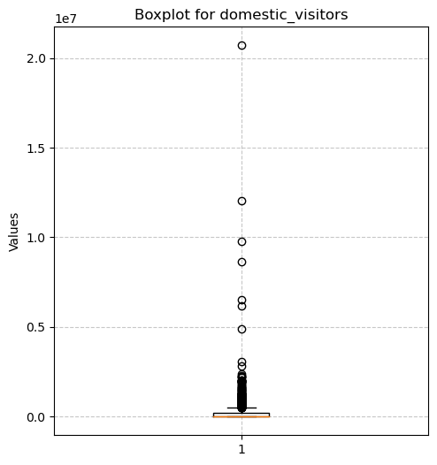

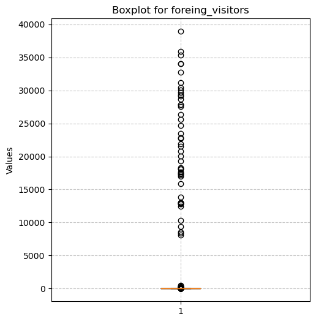

```python
#Now lets plot the boxplot to vew the outliers
outliers(data,data_name,columns)
```

It seams the data is ide spread across the box plot and ther is NO cear Interquartile range for the data Therefor I you cant eliminate any data that is further

#### But i will remove the max for the domestic visitors its too far and looks like an outlier

```python
# Find the index of the row with the maximum value in the specified column
max_index = domestic_visitors['visitors'].idxmax()
print(domestic_visitors.loc[max_index]) # Lets print the value that we will delete
# Remove the row with the maximum value
domestic_visitors = domestic_visitors.drop(max_index, axis=0)
```

```
district       Warangal (Urban)
date        2016-01-02 00:00:00
month                  February
year                       2016
visitors               20703778
Name: 349, dtype: object
```

```python
# meta data
data = [domestic_visitors, foreing_visitors]
data_name = ['domestic_visitors', 'foreing_visitors']
columns = ['district','date','month','year','visitors']
```

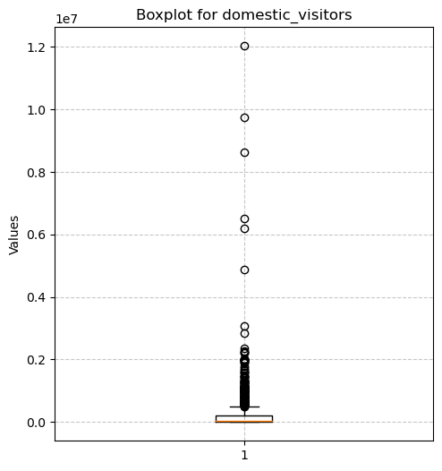

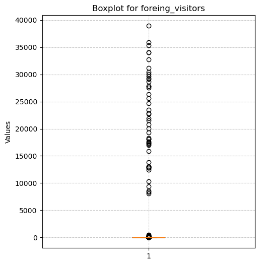

```python
#Checking if its removed
outliers(data,data_name,columns)
```

### Lets view the summary of the data using .describe()

```python
list(map(lambda df: df.describe(include='all').T, data))
```

```
[           count unique                  top freq      first       last  \
 district    1511     33             Adilabad   48        NaT        NaT
 date        1511     48  2019-01-12 00:00:00   33 2016-01-01 2019-01-12
 month       1511     12              January  126        NaT        NaT
 year        1511      4                 2019  396        NaT        NaT
 visitors  1511.0    NaN                  NaN  NaN        NaT        NaT

                    mean            std  min   25%      50%       75%  \
 district            NaN            NaN  NaN   NaN      NaN       NaN
 date                NaN            NaN  NaN   NaN      NaN       NaN
 month               NaN            NaN  NaN   NaN      NaN       NaN
 year                NaN            NaN  NaN   NaN      NaN       NaN
 visitors  222129.630046  628122.803156  0.0  41.5  26179.0  201050.0

                  max
 district         NaN
 date             NaN
 month            NaN
 year             NaN
 visitors  12032661.0  ,
            count unique                  top freq      first       last  \
 district    1512     33             Adilabad   48        NaT        NaT
 date        1512     48  2019-01-12 00:00:00   33 2016-01-01 2019-01-12
 month       1512     12              January  126        NaT        NaT
 year        1512      4                 2019  396        NaT        NaT
 visitors  1512.0    NaN                  NaN  NaN        NaT        NaT

                 mean          std  min  25%  50%  75%      max
 district         NaN          NaN  NaN  NaN  NaN  NaN      NaN
 date             NaN          NaN  NaN  NaN  NaN  NaN      NaN
 month            NaN          NaN  NaN  NaN  NaN  NaN      NaN
 year             NaN          NaN  NaN  NaN  NaN  NaN      NaN
 visitors  700.989418  4089.469823  0.0  0.0  0.0  0.0  38933.0  ]
```

# Data Analysis

```python
# meta data
data = [domestic_visitors, foreing_visitors]
data_name = ['domestic_visitors', 'foreing_visitors']
columns = ['district','date','month','year','visitors']
```

## Request 1: The Top/ Bottom 10 districts that have the higest/Lowest number of domestic visitors overall(2016-2019)

```python
# first we define a function to use to culculate the top ten districts this function will be usable for domestic and forign
top_bottom=[
    #From the largest to the smallest select top_bottom[0] for false
    False,
    #for from bottom selsct top_bottom[1] for True
    True
]
def top10_districts(data,how_much,top_bottom,data_name):
    #first we group by the districts
    districts = data.groupby(['district'])['visitors'].sum().reset_index()
    # now lets sort the data from max to minimum by the column visitors
    top_10 = districts.sort_values(by = ['visitors'], ascending = top_bottom).head(how_much).reset_index(drop=True)
    top_10.index += 1
    # lets Plot a histogram
    plt.figure(figsize=(18, 7))
    plt.bar(top_10['district'],top_10['visitors'])
    plt.xlabel('Districts')
    plt.ylabel('Number of Visitors')
    plt.title(f'{how_much} Districts that have the {"Lowest" if top_bottom else "Highest" } Number of {data_name} For The Period 2016-2019')
    plt.xticks(rotation=45)
    plt.show()
    plt.clf()

    return top_10
```

the Top 10 Districts domestic visitors

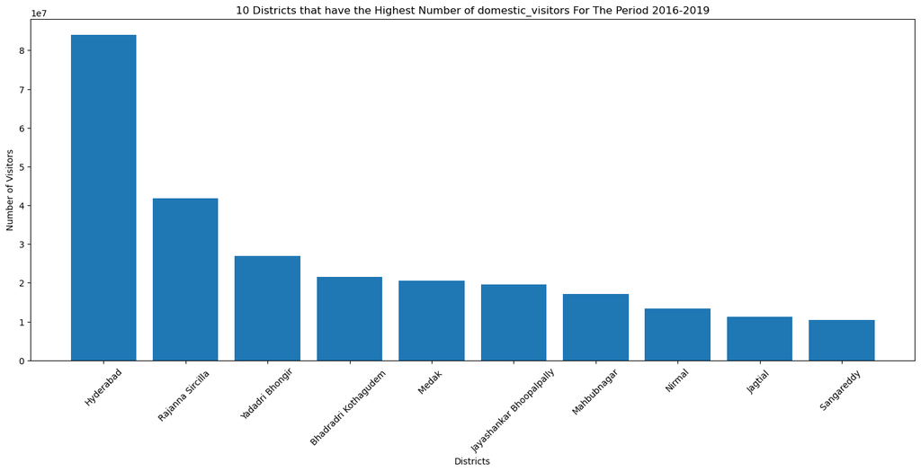

|  | district | visitors |
| --- | --- | --- |
| 1 | Hyderabad | 83900960 |
| 2 | Rajanna Sircilla | 41763276 |
| 3 | Yadadri Bhongir | 26893080 |
| 4 | Bhadradri Kothagudem | 21600962 |
| 5 | Medak | 20542639 |
| 6 | Jayashankar Bhoopalpally | 19632865 |
| 7 | Mahbubnagar | 17180118 |
| 8 | Nirmal | 13315796 |
| 9 | Jagtial | 11303514 |
| 10 | Sangareddy | 10424510 |

```python
#The top 10 districts domestic visitors

top10_districts(data[0],10,top_bottom[0],data_name[0])
```

the Bottom 10 Districts domestic visitors

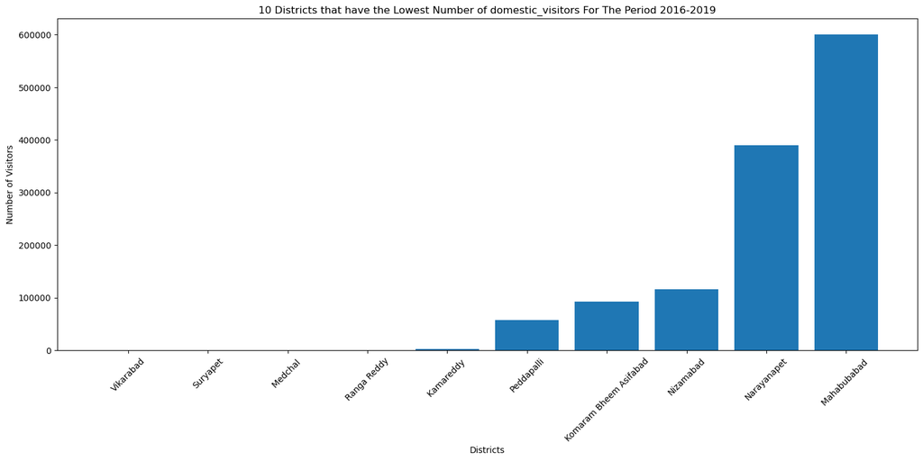

|  | district | visitors |
| --- | --- | --- |
| 1 | Vikarabad | 0 |
| 2 | Suryapet | 0 |
| 3 | Medchal | 0 |
| 4 | Ranga Reddy | 0 |
| 5 | Kamareddy | 1773 |
| 6 | Peddapalli | 56977 |
| 7 | Komaram Bheem Asifabad | 92734 |
| 8 | Nizamabad | 116147 |
| 9 | Narayanapet | 389250 |
| 10 | Mahabubabad | 600697 |

```python
top10_districts(data[0],10,top_bottom[1],data_name[0])
```

the Top 10 Districts Foreing visitors

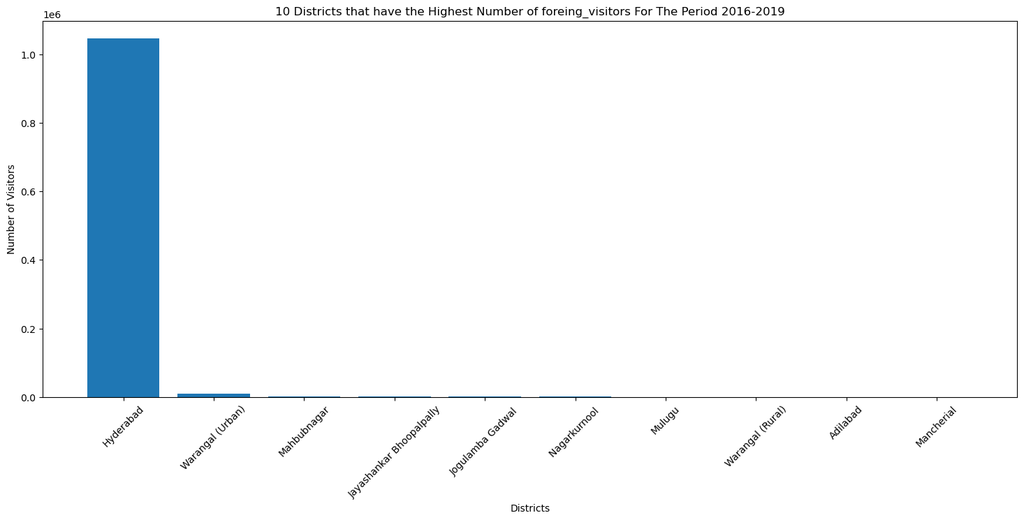

|  | district | visitors |
| --- | --- | --- |
| 1 | Hyderabad | 1044898 |
| 2 | Warangal (Urban) | 8821 |
| 3 | Mahbubnagar | 2282 |
| 4 | Jayashankar Bhoopalpally | 1252 |
| 5 | Jogulamba Gadwal | 945 |
| 6 | Nagarkurnool | 761 |
| 7 | Mulugu | 575 |
| 8 | Warangal (Rural) | 306 |
| 9 | Adilabad | 32 |
| 10 | Mancherial | 10 |

```python
top10_districts(data[1],10,top_bottom[0],data_name[1])
```

the Bottom 10 Districts foreing visitors

[figure not shown]

|  | district | visitors |
| --- | --- | --- |
| 1 | Yadadri Bhongir | 0 |
| 2 | Nalgonda | 0 |
| 3 | Ranga Reddy | 0 |
| 4 | Sangareddy | 0 |
| 5 | Medchal | 0 |
| 6 | Medak | 0 |
| 7 | Siddipet | 0 |
| 8 | Peddapalli | 0 |
| 9 | Komaram Bheem Asifabad | 0 |
| 10 | Mahabubabad | 0 |

```python
top10_districts(data[1],10,top_bottom[1],data_name[1])
```

```python
# we create a usable function that can calcualte the top 3 districts and also can be modified to calculate the bottom 3 districts
#
top_bottom=[
    #From the largest to the smallest select top_bottom[0] for false
    False,
    #for from bottom selsct top_bottom[1] for True
    True
]
def cagr_vistors(data,how_much,top_bottom,data_name):
    #first we group the data by district and year the we find the sum of visitors
    annual_visitors =data.groupby(['district','year'])['visitors'].sum().unstack(fill_value = 0)

    #Calculate CAGR for each district
    cagr =((annual_visitors['2019'] / annual_visitors['2016'])** (1/3)) - 1

    # sort in descending order and get the top or bottom 5 districts
    values = cagr.sort_values(ascending = top_bottom).head(how_much)
    df = values.copy()
    df = pd.DataFrame(df).reset_index().rename(columns={0 : 'CAGR'})
    df.index += 1
    # Plotting the Bar Charts
    colors = ['red' if y < 0 else 'blue' for y in df['CAGR']]

    plt.bar(df['district'],df['CAGR'], color =colors)
    plt.xlabel('Districts')
    plt.ylabel('Number of Visitors')
    plt.title(f'Districts that have the {"Lowest" if top_bottom else "Highest" } C.A.G.R for {data_name} Data, in The Period 2016-2019')
    plt.xticks(rotation=45)
    plt.show()
    plt.clf()
    return df
```

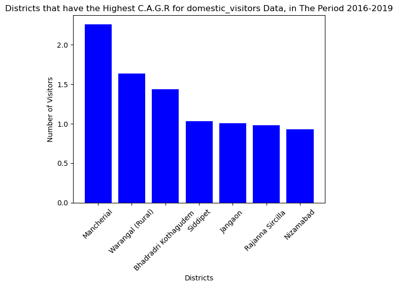

|  | district | CAGR |
| --- | --- | --- |
| 1 | Komaram Bheem Asifabad | inf |
| 2 | Mulugu | inf |
| 3 | Narayanapet | inf |
| 4 | Mancherial | 2.257997 |
| 5 | Warangal (Rural) | 1.631455 |
| 6 | Bhadradri Kothagudem | 1.433875 |
| 7 | Siddipet | 1.027672 |
| 8 | Jangaon | 1.007372 |
| 9 | Rajanna Sircilla | 0.977486 |
| 10 | Nizamabad | 0.930293 |

```python
cagr_vistors(data[0],10,top_bottom[0],data_name[0])
```

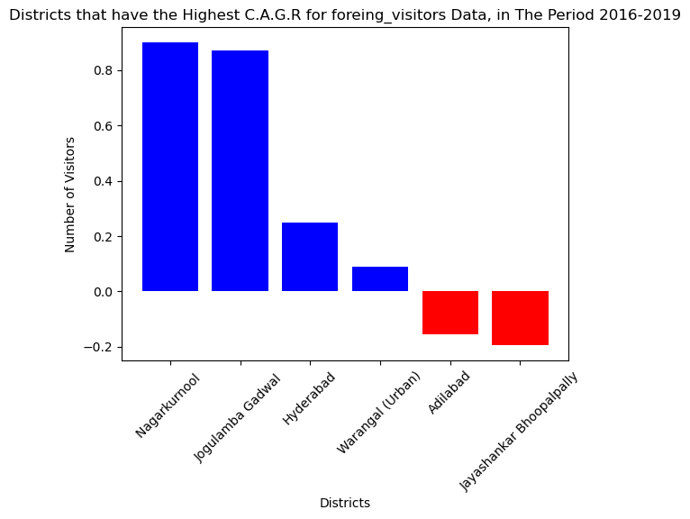

|  | district | CAGR |
| --- | --- | --- |
| 1 | Mancherial | inf |
| 2 | Mulugu | inf |
| 3 | Narayanpet | inf |
| 4 | Nizamabad | inf |
| 5 | Nagarkurnool | 0.900283 |
| 6 | Jogulamba Gadwal | 0.871557 |
| 7 | Hyderabad | 0.249619 |
| 8 | Warangal (Urban) | 0.088630 |
| 9 | Adilabad | -0.156567 |
| 10 | Jayashankar Bhoopalpally | -0.194180 |

```python
cagr_vistors(data[1],10,top_bottom[0],data_name[1])
```

### Request 3:bottom 5 districts based on compounded annual growth rate (CAGR) of visitors between (2016 - 2019)

[figure not shown]

[output not shown]

```python
cagr_vistors(data[1],5,top_bottom[1],data_name[1])
```

Bottom 5 districts with lowest CARG for foreign visitors

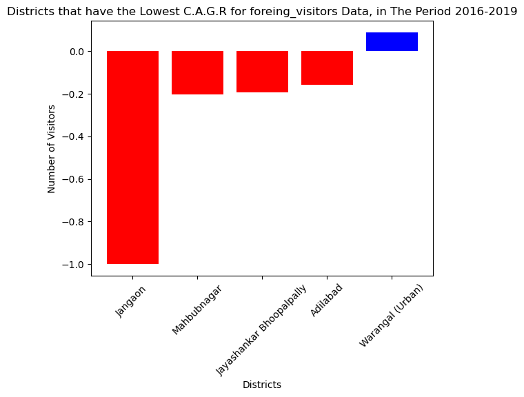

|  | district | CAGR |
| --- | --- | --- |
| 1 | Jangaon | -1.000000 |
| 2 | Mahbubnagar | -0.202659 |
| 3 | Jayashankar Bhoopalpally | -0.194180 |
| 4 | Adilabad | -0.156567 |
| 5 | Warangal (Urban) | 0.088630 |

```python
cagr_vistors(data[1],5,top_bottom[1],data_name[1])
```

### Request 4: Identify Peak and low Season Months (2016 - 2019)

```python
#create a function that creates a lince chart for a specific district that shows how the district is doing across every month and every year
import calendar  # Import the calendar module to get month names

def district_peak_months(data, district, data_name):
    # Create a custom order for months
    month_order = list(calendar.month_name)[1:]  # Get month names in order from January to December

    # Group and sum visitors by district and month, and reset the index
    peak_months = data.groupby(['district', 'month'])['visitors'].sum().reset_index()

    # Filter data for the specified district
    peak_months = peak_months[peak_months['district'] == district]

    # Set the custom month order for plotting
    peak_months['month'] = pd.Categorical(peak_months['month'], categories=month_order, ordered=True)

    # Sort the data by the custom month order
    peak_months = peak_months.sort_values(by='month')

    # Plot Peak and low seasons  for all the months
    plt.figure(figsize=(10, 6))
    plt.plot(peak_months['month'], peak_months['visitors'])
    plt.xlabel('Month')
    plt.ylabel('Number of Visitors')
    plt.title(f'Peak and Low Seasons in {district} ({data_name} Data)')
    plt.xticks(rotation=45)
    plt.show()
    plt.clf()

# Print and view only the months with peak and low season
# Filter data for district given (its already done)
    peak_month = data[data['district'] == district]
    # Group data by month and sum visitors
    monthly_visitors = peak_month.groupby('month')['visitors'].sum().reset_index()

    # Identify peak and low seasons
    peak_season = monthly_visitors[monthly_visitors['visitors'] == monthly_visitors['visitors'].max()].reset_index(drop = True)
    low_season = monthly_visitors[monthly_visitors['visitors'] == monthly_visitors['visitors'].min()].reset_index(drop = True)
    peak_season = print (f'This shows the peak season for the {district} district \n {peak_season}')
    print('\n')
    low_season = print (f'This shows the Low season for the {district} district \n {low_season}')

    return peak_season, low_season
```

Peak and low seasons months for Hyderabad district based on the data domestic Visitors from 2016 to 2019.

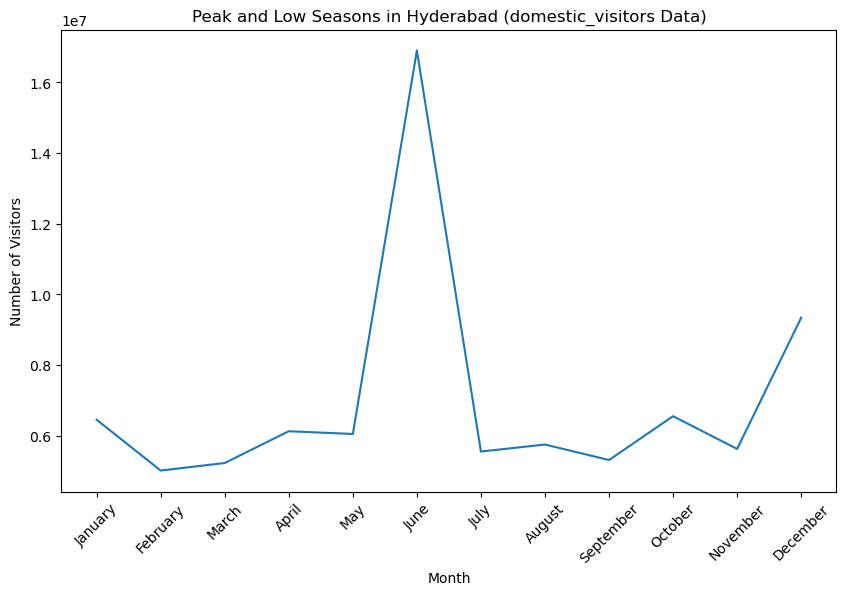

```
This shows the peak season for the Hyderabad district
   month  visitors
0  June  16897783


This shows the Low season for the Hyderabad district
       month  visitors
0  February   5014430
```

```
(None, None)
```

```python
district_peak_months(data[0],'Hyderabad',data_name[0])
```

Peak and low seasons months for Hyderabad district based on the data foreing visitors from 2016 to 2019

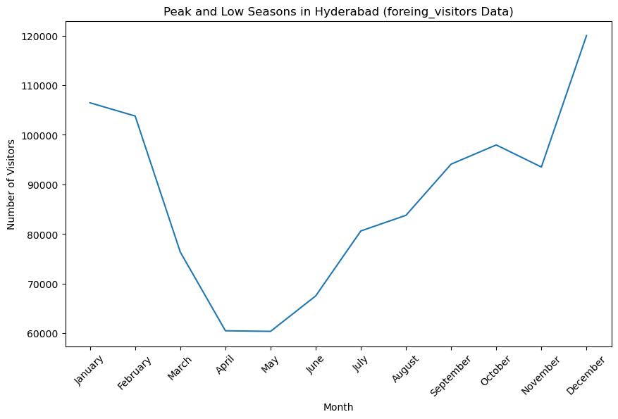

```
This shows the peak season for the Hyderabad district
       month  visitors
0  December    119995


This shows the Low season for the Hyderabad district
   month  visitors
0   May     60376
```

```
(None, None)
```

```python
district_peak_months(data[1],'Hyderabad',data_name[1])
```

### Request 5:Top & Bottom 3 districts with high domestic to foreing tourist ratio

```python
def top_bottom_3_districts_tourist_ratio(data,data_name):
    # Calculate the total domestic and foreign visitors for each district
    domestic_totals = data[0].groupby('district')['visitors'].sum().reset_index()
    foreign_totals = data[1].groupby('district')['visitors'].sum().reset_index()

    # Calculate the tourist ratio (domestic to foreign)
    domestic_totals['tourist_ratio'] = domestic_totals['visitors'] / foreign_totals['visitors']

    # Sort in descending order and get the top 3 and bottom 3 districts
    Lists_values = domestic_totals.sort_values(by='tourist_ratio', ascending=False).drop('visitors', axis = 1).reset_index(drop = True).dropna()
    Lists_values.index +=1
    #Droping All INF values/ Values that have 0 in the Foreing visitors Data frame
    Lists_values = Lists_values[~Lists_values.isin([float('inf')]).any(axis = 1)]

    top_3 = Lists_values.head(3)
    bottom_3 = Lists_values.tail(3).sort_values(by='tourist_ratio', ascending=True)

    top_3 = print(f'      Districts with Highest domestic to foreing tourist ratio   \n \n {top_3}')
    print('\n')
    bottom_3 = print(f'        Districts with Lowest domestic to foreing tourist ratio \n \n{bottom_3}')
    return top_3, bottom_3
```

```python
# Call the function
top_bottom_3_districts_tourist_ratio(data,data_name[0])
```

```
      Districts with Highest domestic to foreing tourist ratio

     district  tourist_ratio
16    Nirmal   6.657898e+06
17  Jangaon    4.131400e+05
18  Adilabad   2.287992e+05


        Districts with Lowest domestic to foreing tourist ratio

            district  tourist_ratio
29         Hyderabad      80.295837
28  Warangal (Urban)    1136.245890
27  Warangal (Rural)    2677.000000
```

```
(None, None)
```

### Request 6: The Top & Bottom 5 districts based on "Population to Tourist Footfall Ratio*" ratio in 2019

This ratio can be found by Ratio : Total Visitors / Total Residents Population in the given year

More data on the population is needed so as to Answer this question Therfore we first skip this till we get more relevant data.

### Request 7: The projected Number of domestic and foreign Visitors in a district (any district as specifide in the input) in 2025 based on the growth rate from previous years

The Insight is to find a better estimate of incomming Tourists count so that the Government can plan the infrastructure better

Now we will check the Hyderabad district.

```python
def projected_tourists_district(data,district, year_start, year_end, projected_year,data_names):
    #chaging the year to int type for esay use when calculating
    for i in range(len(data)):
        data[i]['year'] = data[i]['year'].astype(int)
        # Filter data for Hyderabad district and specified years
        district_data = data[i][(data[i]['district'] == district) & (data[i]['year'] >= year_start) & (data[i]['year'] <= year_end)]

        # Calculate the annual growth rate
        annual_growth_rate = (district_data.groupby('year')['visitors'].sum().pct_change() + 1).mean()
        # Estimate projected tourists for the specified year
        tourists_on_year_specified = district_data[district_data['year'] == year_end]['visitors'].values[0] * (annual_growth_rate ** (projected_year - year_end))
        print(f"The estimated Number Of {data_names[i]} Tourist on {projected_year} will be Around : {tourists_on_year_specified.round()} \n")
```

```python
# Call the function with the desired years

# projected_tourists_hyderabad(data,district, year_start, year_end, projected_year,data_names)
data_names = ('Domestic', 'Foreign')
projected_tourists_district(data,'Hyderabad', 2016, 2019, 2025,data_names)
```

```
The estimated Number Of Domestic Tourist on 2025 will be Around : 586244.0

The estimated Number Of Foreign Tourist on 2025 will be Around : 147994.0
```

### Request 8: The projected revenue for Districts given the average revenue for the domestic and foreign visitors

NB we will oberve for the district of Hyderabad but you can change to observe diffent districts

```python
def projected_revenue_district(data,district, year_start, year_end, projected_year, avg_revenue_foreign, avg_revenue_domestic,data_names):
        #chaging the year to int type for esay use when calculating
    for i in range(len(data)):
        data[i]['year'] = data[i]['year'].astype(int)
        # Filter data for Hyderabad district and specified years
        district_data = data[i][(data[i]['district'] == district) & (data[i]['year'] >= year_start) & (data[i]['year'] <= year_end)]

        # Calculate the annual growth rate
        annual_growth_rate = (district_data.groupby('year')['visitors'].sum().pct_change() + 1).mean()

        # Estimate projected tourists for the specified year
        tourists_2025 = district_data[district_data['year'] == year_end]['visitors'].values[0] * (annual_growth_rate ** (projected_year - year_end))

        # Estimate projected revenue
        projected_revenue = (tourists_2025 * avg_revenue_foreign) + ((1 - tourists_2025) * avg_revenue_domestic)

        print (f'The {data_names[i]} projected Revenue for {district} district for the year {projected_year} is around {projected_revenue.round(2)} \n')
```

```python
# Call the function with the desired parameters
#projected_revenue_hyderabad(data, year_start, year_end, projected_year, avg_revenue_foreign, avg_revenue_domestic,data_names)
projected_revenue_district(data,'Hyderabad', 2016, 2019, 2025, 5600.00, 1200.00, data_names)
```

```
The Domestic projected Revenue for Hyderabad district for the year 2025 is around 2579476814.23

The Foreign projected Revenue for Hyderabad district for the year 2025 is around 651173112.24
```

### Request 9: Districts with The Highest Potential for Tourisim Growth.

some recomendations added

```python
def districts_highest_potential(data):
    for i in range(len(data)):
        # Calculate the compounded annual growth rate (CAGR) for each district
        annual_visitors = data[i].groupby(['district', 'year'])['visitors'].sum().unstack(fill_value=0)
        cagr = ((annual_visitors[2019] / annual_visitors[2016]) ** (1/3)) - 1

        # Identify districts with the highest potential (top 3)
        highest_potential = cagr.sort_values(ascending=False).head(3)
        #lets print the districts
        print(f'Districts with Highest Potential {data_names[i]} visitors : {highest_potential.index.tolist()} \n')
    # Recommend actions for tourism growth

    recommendations = {

        'Actions': [
                    '1. Promote cultural festivals and events.',
        '           2. Improve infrastructure and accommodation.',
        '           3. Enhance marketing efforts targeting international tourists.'
        ]
    }

    return recommendations
```

```python
# Call the function
districts_highest_potential(data)
```

```
Districts with Highest Potential Domestic visitors : ['Komaram Bheem Asifabad', 'Mulugu', 'Narayanapet']

Districts with Highest Potential Foreign visitors : ['Mancherial', 'Mulugu', 'Narayanpet']
```

```
{'Actions': ['1. Promote cultural festivals and events.',
  '           2. Improve infrastructure and accommodation.',
  '           3. Enhance marketing efforts targeting international tourists.']}
```

### Request 10: Recommend cultural and corporate events to boost tourism

```python
def recommend_events(data, district, year):
    # Filter data for the specified district and year
    district_data = data[(data['district'] == district) & (data['year'] == year)]

    # Determine the type of events based on analysis
    events_recommendation = {
        'District': district,
        'Year': year,
        'Data': district_data,
        'Recommended Events': [
            'Cultural festivals showcasing local traditions and art.',
            'Corporate conventions and conferences to attract business travelers.',
            'Collaborative events with neighboring districts for regional tourism.'
        ]
    }

    return events_recommendation
```

```python
# Call the function with desired district and year
#recommend_events(data, district, year)
recommend_events(data[1], 'Hyderabad', 2019)
```

```
{'District': 'Hyderabad',
 'Year': 2019,
 'Data':        district       date      month  year  visitors
 1140  Hyderabad 2019-01-01    January  2019     35920
 1141  Hyderabad 2019-01-02   February  2019     25621
 1142  Hyderabad 2019-01-03      March  2019     21929
 1143  Hyderabad 2019-01-04      April  2019     18267
 1144  Hyderabad 2019-01-05        May  2019     17317
 1145  Hyderabad 2019-01-06       June  2019     20077
 1146  Hyderabad 2019-01-07       July  2019     27874
 1147  Hyderabad 2019-01-08     August  2019     22725
 1148  Hyderabad 2019-01-09  September  2019     34018
 1149  Hyderabad 2019-01-10    October  2019     28706
 1150  Hyderabad 2019-01-11   November  2019     32762
 1151  Hyderabad 2019-01-12   December  2019     34084,
 'Recommended Events': ['Cultural festivals showcasing local traditions and art.',
  'Corporate conventions and conferences to attract business travelers.',
  'Collaborative events with neighboring districts for regional tourism.']}
```

### Request 11: Provide additional recommendations to boost Telangana tourism

```python
def additional_recommendations(data):
    recommendations = [
        'Improve safety and security for tourists.',
        'Enhance cleanliness and hygiene standards in tourist areas.',
        'Collaborate with travel agencies to offer attractive tour packages.',
        'Promote eco-tourism initiatives to attract nature enthusiasts.',
        'Establish tourism information centers for visitors.'
    ]

    return recommendations

# Call the function
additional_recommendations(data[0])
```

```
['Improve safety and security for tourists.',
 'Enhance cleanliness and hygiene standards in tourist areas.',
 'Collaborate with travel agencies to offer attractive tour packages.',
 'Promote eco-tourism initiatives to attract nature enthusiasts.',
 'Establish tourism information centers for visitors.']
```

# Exporting The data we have being using so as to use it again

```python
data[0].to_csv('Data For machine learning/Domestic_visitor_Output_2.csv', encoding= 'utf-8')
data[1].to_csv('Data For machine learning/foreing_visitor_Output_2.csv', encoding= 'utf-8')
```